# Chapter 4 Regression - Linear models

## 1. Multiple Linear Regression

**Regression** is a method used to build a mathematical relationship between predictors (independent variables) and a dependent (response) variable.

**Multiple regression** extends simple linear regression by allowing more than one independent (explanatory) variable. While simple regression uses a single predictor, multiple regression fits a model for one dependent variable based on multiple predictors. This makes it a powerful tool in predictive analytics and statistical modeling. By incorporating multiple predictors, analysts can better understand the relationships among variables and improve predictive performance. Multiple regression is widely applied in fields such as finance, marketing, healthcare, and environmental sciences.

### Applications of Multiple Regression

#### Economics and Finance

- **Stock Price Prediction:** Estimate stock prices using predictors such as interest rates, market indices, and company financials.
- **Economic Forecasting:** Predict GDP growth, inflation rates, or unemployment using macroeconomic indicators.

#### Environmental Sciences

- **Climate Modeling:** Forecast climate patterns, temperature changes, or environmental outcomes using meteorological and geographic variables.
- **Air Quality Prediction:** Predict pollution levels from emissions, weather conditions, and geographic features.

## General Model

$$ y_i = \beta_0 + \beta_1 x_{1,i} + \beta_2 x_{2,i} + \ldots + \beta_p x_{p,i} + \varepsilon_{i} $$

where:

- $y_i$ = dependent variable
- $x_{1,i}, x_{2,i}, \ldots, x_{p,i}$ = independent variables
- $\beta_0, \beta_1, \ldots, \beta_p$ = regression coefficients
- $\varepsilon_i$ = error term

> Note: *"Linear"* refers to the linearity in parameters, not necessarily in predictors.

## Least Squares Estimation (Matrix Form)

$$ \hat{\boldsymbol{\beta}} = (X^T X)^{-1} X^T Y $$

where:

- $\boldsymbol{\beta}$: vector of coefficients (including the intercept $\beta_0$)
- $X$: design matrix of size $n \times (p+1)$
- $Y$: vector of observed dependent variable values

## Prediction for a new case

In predictive modeling, a fitted multiple regression model is used to generate **point predictions** and **uncertainty intervals** for new cases.

Let the fitted model be $$ \hat{y}_i = \hat{\beta}_0 + \hat{\beta}_1 x_{1,i} + \cdots + \hat{\beta}_p x_{p,i}. $$ For a new feature vector $x_{\text{new}} = (x_{1,\text{new}}, \ldots, x_{p,\text{new}})$, define the augmented vector $$ \mathbf{x}_{\text{new}} = (1, x_{1,\text{new}}, \ldots, x_{p,\text{new}})^\top. $$ Then the **predicted value** is $$ \hat{y}_{\text{new}} = \mathbf{x}_{\text{new}}^\top \hat{\boldsymbol{\beta}}. $$

### Example: Multiple Regression with Airquality Data

We will use the **airquality** dataset in R:

- **Source**: New York State Department of Conservation (ozone data) and the National Weather Service (meteorological data), cited in Chambers et al. (1985).
- **Description**: Daily air quality measurements in New York, from May to September 1973.
- **Structure**: A data frame with 153 observations on 6 variables.

Reference: [R Documentation – airquality](https://www.rdocumentation.org/packages/datasets/versions/3.6.2/topics/airquality)

```r
#Example
data(airquality)
head(airquality)

#How many missing values in each variable
colSums(is.na(airquality))
```

A data.frame: 6 × 6

|  | Ozone <int> | Solar.R <int> | Wind <dbl> | Temp <int> | Month <int> | Day <int> |
| --- | --- | --- | --- | --- | --- | --- |
| 1 | 41 | 190 | 7.4 | 67 | 5 | 1 |
| 2 | 36 | 118 | 8.0 | 72 | 5 | 2 |
| 3 | 12 | 149 | 12.6 | 74 | 5 | 3 |
| 4 | 18 | 313 | 11.5 | 62 | 5 | 4 |
| 5 | NA | NA | 14.3 | 56 | 5 | 5 |
| 6 | 28 | NA | 14.9 | 66 | 5 | 6 |

**Ozone**

37

**Solar.R**

7

**Wind**

0

**Temp**

0

**Month**

0

**Day**

0

A matrix: 6 × 6 of type dbl

|  | Ozone | Solar.R | Wind | Temp | Month | Day |
| --- | --- | --- | --- | --- | --- | --- |
| Ozone | 1.000000000 | 0.34834169 | -0.61249658 | 0.6985414 | 0.142885168 | -0.005189769 |
| Solar.R | 0.348341693 | 1.00000000 | -0.12718345 | 0.2940876 | -0.074066683 | -0.057753801 |
| Wind | -0.612496576 | -0.12718345 | 1.00000000 | -0.4971897 | -0.194495804 | 0.049871017 |
| Temp | 0.698541410 | 0.29408764 | -0.49718972 | 1.0000000 | 0.403971709 | -0.096545800 |
| Month | 0.142885168 | -0.07406668 | -0.19449580 | 0.4039717 | 1.000000000 | -0.009001079 |
| Day | -0.005189769 | -0.05775380 | 0.04987102 | -0.0965458 | -0.009001079 | 1.000000000 |

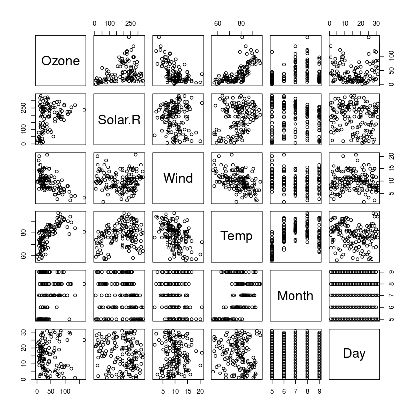

```r
#Create a new data set without missing values by delete the cases with missing values
dat = na.omit(airquality)

#Correlation plot
cor(dat)


#scatter plot matrix
pairs(airquality)
```

```r
#To build a predictive model using all other variables to predict Ozone
fit = lm(Ozone~ Solar.R+ Wind + Temp + Month + Day,  data = dat)
summary(fit)
```

```
Call:
lm(formula = Ozone ~ Solar.R + Wind + Temp + Month + Day, data = dat)

Residuals:
    Min      1Q  Median      3Q     Max
-37.014 -12.284  -3.302   8.454  95.348

Coefficients:
             Estimate Std. Error t value Pr(>|t|)
(Intercept) -64.11632   23.48249  -2.730  0.00742 **
Solar.R       0.05027    0.02342   2.147  0.03411 *
Wind         -3.31844    0.64451  -5.149 1.23e-06 ***
Temp          1.89579    0.27389   6.922 3.66e-10 ***
Month        -3.03996    1.51346  -2.009  0.04714 *
Day           0.27388    0.22967   1.192  0.23576
---
Signif. codes:  0 ‘***’ 0.001 ‘**’ 0.01 ‘*’ 0.05 ‘.’ 0.1 ‘ ’ 1

Residual standard error: 20.86 on 105 degrees of freedom
Multiple R-squared:  0.6249,	Adjusted R-squared:  0.6071
F-statistic: 34.99 on 5 and 105 DF,  p-value: < 2.2e-16
```

```r
#To build a predictive model using all other variables to predict Ozone
fit.1 = lm(Ozone~ Solar.R+ Wind + Temp + Month + Day,  data = airquality)
fit.1

summary(fit.1)
```

```
Call:
lm(formula = Ozone ~ Solar.R + Wind + Temp + Month + Day, data = airquality)

Coefficients:
(Intercept)      Solar.R         Wind         Temp        Month          Day
  -64.11632      0.05027     -3.31844      1.89579     -3.03996      0.27388
```

```
Call:
lm(formula = Ozone ~ Solar.R + Wind + Temp + Month + Day, data = airquality)

Residuals:
    Min      1Q  Median      3Q     Max
-37.014 -12.284  -3.302   8.454  95.348

Coefficients:
             Estimate Std. Error t value Pr(>|t|)
(Intercept) -64.11632   23.48249  -2.730  0.00742 **
Solar.R       0.05027    0.02342   2.147  0.03411 *
Wind         -3.31844    0.64451  -5.149 1.23e-06 ***
Temp          1.89579    0.27389   6.922 3.66e-10 ***
Month        -3.03996    1.51346  -2.009  0.04714 *
Day           0.27388    0.22967   1.192  0.23576
---
Signif. codes:  0 ‘***’ 0.001 ‘**’ 0.01 ‘*’ 0.05 ‘.’ 0.1 ‘ ’ 1

Residual standard error: 20.86 on 105 degrees of freedom
  (42 observations deleted due to missingness)
Multiple R-squared:  0.6249,	Adjusted R-squared:  0.6071
F-statistic: 34.99 on 5 and 105 DF,  p-value: < 2.2e-16
```

## Feature Interaction

When a model makes a prediction based on two features, the prediction can be decomposed into four components:

1. **Constant term**  
   Represents the baseline prediction when both features are at their reference values (often the intercept).
2. **First feature effect**  
   Contribution to the prediction attributed solely to the first feature, while holding the second feature constant.
3. **Second feature effect**  
   Contribution to the prediction attributed solely to the second feature, while holding the first feature constant.
4. **Interaction term**  
   Captures the combined effect of both features on the prediction, beyond their individual contributions.  
   In other words, it represents the change in the prediction that results when the two features are varied together, accounting for the main effects of each feature.  
   The interaction effect occurs when the effect of one feature depends on the value of the other feature.

## Feature Engineering

Feature engineering is a crucial step in data science that involves transforming raw data into more informative and useful inputs (features) for machine learning algorithms. This preprocessing step includes selecting, creating, modifying, and combining variables to enhance the predictive power of models. High-quality features often make a bigger difference to predictive accuracy than the choice of model itself.

### Common Techniques

- **Feature selection**  
  Identify and select the most relevant features from the raw data, which can improve model performance by removing noise or irrelevant variables.
- **Model selection criteria**  
  To choose the best model, commonly used strategies include Mallows’ $C_p$, Akaike Information Criterion (AIC), and Bayesian Information Criterion (BIC).

  $$ AIC = -2 \times \text{Log-likelihood} + 2p $$

  Alternatively, the `extractAIC()` function can calculate both AIC and BIC.  
  By comparing AIC or BIC values across different models, we select the model with the **smaller value**.

## Stepwise Regression

Stepwise regression is a model selection method that iteratively adds or removes predictors based on selection criteria such as AIC or BIC.

### R Example

```
# Fit initial model
lm.fit <- lm(Ozone ~ Solar.R + Wind + Temp + Month, data = airquality)

# Stepwise selection using AIC and BIC
step(lm.fit, direction = "both", k = log(nrow(airquality)), trace = 0)
```

```r
#create an interaction term between Wind and Temp
dat$WindTemp = dat$Wind * dat$Temp

#create an interaction term between Solor.R and Temp
dat$S3Temp = (dat$Solar-2)^3 * dat$Temp

fit.2 = lm(Ozone~ Solar.R+ Wind + Temp + Month + Day + WindTemp + S3Temp ,  data = dat)
summary(fit.2)

#Adding a few more ploynomial terms of wind

fit.3 = lm(Ozone~ Solar.R+ Wind + Temp + Month + Day + WindTemp + S3Temp + I(Wind^2) +  I(Wind^3),  data = dat)

summary(fit.3)
```

```
Call:
lm(formula = Ozone ~ Solar.R + Wind + Temp + Month + Day + WindTemp +
    S3Temp, data = dat)

Residuals:
    Min      1Q  Median      3Q     Max
-36.414 -12.007  -2.062   6.044  93.455

Coefficients:
              Estimate Std. Error t value Pr(>|t|)
(Intercept) -2.459e+02  4.696e+01  -5.237 8.68e-07 ***
Solar.R      8.617e-02  5.252e-02   1.641 0.103904
Wind         1.426e+01  4.083e+00   3.492 0.000707 ***
Temp         4.128e+00  5.712e-01   7.227 8.90e-11 ***
Month       -2.999e+00  1.467e+00  -2.043 0.043560 *
Day          3.015e-01  2.130e-01   1.415 0.159989
WindTemp    -2.256e-01  5.194e-02  -4.343 3.30e-05 ***
S3Temp      -4.074e-09  6.784e-09  -0.601 0.549457
---
Signif. codes:  0 ‘***’ 0.001 ‘**’ 0.01 ‘*’ 0.05 ‘.’ 0.1 ‘ ’ 1

Residual standard error: 19.34 on 103 degrees of freedom
Multiple R-squared:  0.6837,	Adjusted R-squared:  0.6623
F-statistic: 31.81 on 7 and 103 DF,  p-value: < 2.2e-16
```

```
Call:
lm(formula = Ozone ~ Solar.R + Wind + Temp + Month + Day + WindTemp +
    S3Temp + I(Wind^2) + I(Wind^3), data = dat)

Residuals:
    Min      1Q  Median      3Q     Max
-46.220 -10.900  -1.727   8.933  69.887

Coefficients:
              Estimate Std. Error t value Pr(>|t|)
(Intercept) -2.754e+01  7.906e+01  -0.348   0.7283
Solar.R      8.336e-02  5.032e-02   1.657   0.1007
Wind        -1.671e+01  1.068e+01  -1.564   0.1208
Temp         2.289e+00  7.898e-01   2.898   0.0046 **
Month       -3.004e+00  1.415e+00  -2.122   0.0363 *
Day          3.467e-01  2.045e-01   1.696   0.0931 .
WindTemp    -5.969e-02  7.160e-02  -0.834   0.4065
S3Temp      -4.263e-09  6.498e-09  -0.656   0.5133
I(Wind^2)    1.254e+00  6.516e-01   1.925   0.0570 .
I(Wind^3)   -2.371e-02  1.857e-02  -1.276   0.2047
---
Signif. codes:  0 ‘***’ 0.001 ‘**’ 0.01 ‘*’ 0.05 ‘.’ 0.1 ‘ ’ 1

Residual standard error: 18.52 on 101 degrees of freedom
Multiple R-squared:  0.7155,	Adjusted R-squared:  0.6902
F-statistic: 28.23 on 9 and 101 DF,  p-value: < 2.2e-16
```

```r
#Stepwise selection (bidirectional)
step(fit.3, direction = "both", trace = 0)

#linear regression using the selected features
fit.4 = lm(formula = Ozone ~ Solar.R + Wind + Temp + Month + Day + I(Wind^2), data = dat)

summary(fit.4)
```

```
Call:
lm(formula = Ozone ~ Solar.R + Wind + Temp + Month + Day + I(Wind^2),
    data = dat)

Coefficients:
(Intercept)      Solar.R         Wind         Temp        Month          Day
    6.44325      0.05338    -15.12230      1.66023     -2.53453      0.34465
  I(Wind^2)
    0.53656
```

```
Call:
lm(formula = Ozone ~ Solar.R + Wind + Temp + Month + Day + I(Wind^2),
    data = dat)

Residuals:
    Min      1Q  Median      3Q     Max
-37.701 -11.068  -2.474   7.722  71.246

Coefficients:
             Estimate Std. Error t value Pr(>|t|)
(Intercept)   6.44325   24.58990   0.262   0.7938
Solar.R       0.05338    0.02080   2.567   0.0117 *
Wind        -15.12230    2.25600  -6.703 1.08e-09 ***
Temp          1.66023    0.24699   6.722 9.89e-10 ***
Month        -2.53453    1.34669  -1.882   0.0626 .
Day           0.34465    0.20429   1.687   0.0946 .
I(Wind^2)     0.53656    0.09920   5.409 4.07e-07 ***
---
Signif. codes:  0 ‘***’ 0.001 ‘**’ 0.01 ‘*’ 0.05 ‘.’ 0.1 ‘ ’ 1

Residual standard error: 18.52 on 104 degrees of freedom
Multiple R-squared:  0.7073,	Adjusted R-squared:  0.6904
F-statistic: 41.88 on 6 and 104 DF,  p-value: < 2.2e-16
```

```r
#Stepwise selection (backwards)
step(fit.3, direction = "back", trace = 1)


#The model selected may not be the same if different stepwise selection is used.
```

```
Start:  AIC=657.53
Ozone ~ Solar.R + Wind + Temp + Month + Day + WindTemp + S3Temp +
    I(Wind^2) + I(Wind^3)

            Df Sum of Sq   RSS    AIC
- S3Temp     1    147.65 34796 656.00
- WindTemp   1    238.37 34887 656.29
- I(Wind^3)  1    558.94 35207 657.30
<none>                   34648 657.53
- Wind       1    839.62 35488 658.18
- Solar.R    1    941.57 35590 658.50
- Day        1    986.24 35635 658.64
- I(Wind^2)  1   1271.17 35920 659.53
- Month      1   1545.24 36194 660.37
- Temp       1   2881.66 37530 664.39

Step:  AIC=656
Ozone ~ Solar.R + Wind + Temp + Month + Day + WindTemp + I(Wind^2) +
    I(Wind^3)

            Df Sum of Sq   RSS    AIC
- WindTemp   1    237.56 35034 654.75
- I(Wind^3)  1    561.10 35357 655.77
<none>                   34796 656.00
- Wind       1    844.47 35641 656.66
- Day        1    980.70 35777 657.08
- I(Wind^2)  1   1272.27 36068 657.98
- Month      1   1398.50 36195 658.37
- Solar.R    1   2232.31 37028 660.90
- Temp       1   2846.24 37642 662.73

Step:  AIC=654.75
Ozone ~ Solar.R + Wind + Temp + Month + Day + I(Wind^2) + I(Wind^3)

            Df Sum of Sq   RSS    AIC
- I(Wind^3)  1     619.4 35653 654.70
<none>                   35034 654.75
- Day        1    1006.6 36040 655.90
- Month      1    1406.4 36440 657.12
- I(Wind^2)  1    1619.7 36653 657.77
- Solar.R    1    2125.6 37159 659.29
- Wind       1    4226.0 39260 665.39
- Temp       1   15285.3 50319 692.94

Step:  AIC=654.7
Ozone ~ Solar.R + Wind + Temp + Month + Day + I(Wind^2)

            Df Sum of Sq   RSS    AIC
<none>                   35653 654.70
- Day        1     975.7 36629 655.70
- Month      1    1214.3 36867 656.42
- Solar.R    1    2258.9 37912 659.52
- I(Wind^2)  1   10030.0 45683 680.21
- Wind       1   15403.5 51056 692.56
- Temp       1   15489.8 51143 692.75
```

```
Call:
lm(formula = Ozone ~ Solar.R + Wind + Temp + Month + Day + I(Wind^2),
    data = dat)

Coefficients:
(Intercept)      Solar.R         Wind         Temp        Month          Day
    6.44325      0.05338    -15.12230      1.66023     -2.53453      0.34465
  I(Wind^2)
    0.53656
```

```r
#Forward stepwise selection
fit.0= lm(formula = Ozone ~ 1, data = dat)
step(fit.0 , direction='forward', scope=formula(fit.3), trace=1)
```

```
Start:  AIC=779.07
Ozone ~ 1

            Df Sum of Sq    RSS    AIC
+ Temp       1     59434  62367 706.77
+ Wind       1     45694  76108 728.87
+ I(Wind^2)  1     32004  89798 747.23
+ WindTemp   1     24804  96998 755.79
+ I(Wind^3)  1     21245 100556 759.79
+ Solar.R    1     14780 107022 766.71
+ S3Temp     1      9688 112114 771.87
+ Month      1      2487 119315 778.78
<none>                   121802 779.07
+ Day        1         3 121799 781.07

Step:  AIC=706.77
Ozone ~ Temp

            Df Sum of Sq   RSS    AIC
+ WindTemp   1   13792.4 48575 681.03
+ Wind       1   11378.5 50989 686.41
+ I(Wind^2)  1    6016.9 56351 697.51
+ Month      1    2824.7 59543 703.63
+ I(Wind^3)  1    2816.3 59551 703.64
+ Solar.R    1    2723.1 59644 703.82
+ S3Temp     1    1882.6 60485 705.37
<none>                   62367 706.77
+ Day        1     476.5 61891 707.92

Step:  AIC=681.03
Ozone ~ Temp + WindTemp

            Df Sum of Sq   RSS    AIC
+ I(Wind^2)  1    7367.6 41207 664.77
+ I(Wind^3)  1    7110.2 41465 665.46
+ Wind       1    4180.9 44394 673.04
+ Solar.R    1    3138.3 45437 675.61
+ S3Temp     1    2726.9 45848 676.62
+ Month      1    2667.2 45908 676.76
<none>                   48575 681.03
```

[output cut: 28 more lines]

```
            Df Sum of Sq   RSS    AIC
+ Day        1    905.87 35680 654.78
<none>                   36586 655.57
+ Wind       1    280.07 36306 656.71
+ S3Temp     1    146.70 36440 657.12
+ I(Wind^3)  1     43.78 36542 657.43

Step:  AIC=654.78
Ozone ~ Temp + WindTemp + I(Wind^2) + Solar.R + Month + Day

            Df Sum of Sq   RSS    AIC
<none>                   35680 654.78
+ Wind       1    323.27 35357 655.77
+ S3Temp     1    152.35 35528 656.31
+ I(Wind^3)  1     39.90 35641 656.66
```

```
Call:
lm(formula = Ozone ~ Temp + WindTemp + I(Wind^2) + Solar.R +
    Month + Day, data = dat)

Coefficients:
(Intercept)         Temp     WindTemp    I(Wind^2)      Solar.R        Month
 -129.02689      3.06960     -0.13290      0.32046      0.05634     -2.56463
        Day
    0.33191
```

```r
# Feature engineering
# polynomial feature: Wind + I(Wind^2) +  I(Wind^3),  a polynomial to the order of 3
# I(Wind^2) =  wind^2
fit.2 = lm(Ozone~ Solar.R+ Wind + I(Wind^2) +  I(Wind^3) + Temp + Month + Day,  data = airquality)
fit.2

#without interactions , two features
fit.2 = lm(Ozone~ Solar.R+ Wind,  data = airquality)


#interactions , 2 features with interaction
#airquality$inter.Solor.Wind = (airquality$Solar.R - ...) * airquality$Wind
fit.3 = lm(Ozone~ Solar.R * Wind ,  data = airquality)
summary(fit.3)

#interactions , more features, with a three way interaction
fit.4 = lm(Ozone~ Solar.R*Wind*Month,  data = airquality)
summary(fit.4)
```

[output not shown]

```
Call:
lm(formula = Ozone ~ Solar.R * Wind, data = airquality)

Residuals:
    Min      1Q  Median      3Q     Max
-48.694 -17.200  -4.384  12.740  78.218

Coefficients:
              Estimate Std. Error t value Pr(>|t|)
(Intercept)  34.467686  17.634602   1.955 0.053246 .
Solar.R       0.324141   0.083928   3.862 0.000193 ***
Wind         -1.594546   1.508979  -1.057 0.293026
Solar.R:Wind -0.020279   0.007246  -2.799 0.006089 **
---
Signif. codes:  0 ‘***’ 0.001 ‘**’ 0.01 ‘*’ 0.05 ‘.’ 0.1 ‘ ’ 1

Residual standard error: 24.16 on 107 degrees of freedom
  (42 observations deleted due to missingness)
Multiple R-squared:  0.487,	Adjusted R-squared:  0.4727
F-statistic: 33.86 on 3 and 107 DF,  p-value: 1.807e-15
```

```
Call:
lm(formula = Ozone ~ Solar.R * Wind * Month, data = airquality)

Residuals:
    Min      1Q  Median      3Q     Max
-56.511 -17.321  -3.307  12.901  69.640

Coefficients:
                    Estimate Std. Error t value Pr(>|t|)
(Intercept)        73.354880  83.019670   0.884    0.379
Solar.R            -0.302174   0.426066  -0.709    0.480
Wind               -4.364846   6.657808  -0.656    0.514
Month              -6.633092  11.799124  -0.562    0.575
Solar.R:Wind        0.028076   0.035025   0.802    0.425
Solar.R:Month       0.091987   0.061372   1.499    0.137
Wind:Month          0.481245   0.968511   0.497    0.620
Solar.R:Wind:Month -0.007125   0.005138  -1.387    0.169

Residual standard error: 23.96 on 103 degrees of freedom
  (42 observations deleted due to missingness)
Multiple R-squared:  0.5144,	Adjusted R-squared:  0.4814
F-statistic: 15.59 on 7 and 103 DF,  p-value: 8.616e-14
```

```r
# Feature selection
fit.5 = lm(Ozone~ Solar.R+ Wind + I(Wind^2) +  I(Wind^3) + Temp + Month + Day + Wind*Temp*Month*Day,  data = airquality)
fit.5
#Too many variables, which variables should be included.
```

```
Call:
lm(formula = Ozone ~ Solar.R + Wind + I(Wind^2) + I(Wind^3) +
    Temp + Month + Day + Wind * Temp * Month * Day, data = airquality)

Coefficients:
        (Intercept)              Solar.R                 Wind
         -4.624e+02            6.156e-02            5.355e+01
          I(Wind^2)            I(Wind^3)                 Temp
          1.484e+00           -2.963e-02            9.243e+00
              Month                  Day            Wind:Temp
          5.290e+01            1.272e+01           -1.132e+00
         Wind:Month           Temp:Month             Wind:Day
         -1.090e+01           -8.883e-01           -2.411e+00
           Temp:Day            Month:Day      Wind:Temp:Month
         -1.854e-01           -1.368e+00            1.576e-01
      Wind:Temp:Day       Wind:Month:Day       Temp:Month:Day
          3.397e-02            3.632e-01            2.151e-02
Wind:Temp:Month:Day
         -5.056e-03
```

# Model selection using step function in R for linear models

Forward selection begins with an empty model, adding variables based on their significance until no additional relevant variables remain. It's important to note that forward selection and backward elimination may not yield the same final model.

The backward elimination method starts with a full model with all variables and then removes one variable each time to test its importance.

Bidirectional elimination is a combination of the first two methods.

```r
#Forward selection
#empty model without any variable, then adding one by one until sufficient number of variables are selected
fit0 = lm(Ozone ~ 1, data =dat)

#A model includes all other variables
fit=  lm(Ozone~., data=dat)
#Stepwise forward selection
step(fit0 , direction='forward', scope=formula(fit), trace=1)
```

```
Start:  AIC=779.07
Ozone ~ 1

          Df Sum of Sq    RSS    AIC
+ Temp     1     59434  62367 706.77
+ Wind     1     45694  76108 728.87
+ Solar.R  1     14780 107022 766.71
+ Month    1      2487 119315 778.78
<none>                 121802 779.07
+ Day      1         3 121799 781.07

Step:  AIC=706.77
Ozone ~ Temp

          Df Sum of Sq   RSS    AIC
+ Wind     1   11378.5 50989 686.41
+ Month    1    2824.7 59543 703.63
+ Solar.R  1    2723.1 59644 703.82
<none>                 62367 706.77
+ Day      1     476.5 61891 707.92

Step:  AIC=686.41
Ozone ~ Temp + Wind

          Df Sum of Sq   RSS    AIC
+ Solar.R  1   2986.17 48003 681.71
+ Month    1   2734.79 48254 682.29
<none>                 50989 686.41
+ Day      1    486.59 50502 687.35

Step:  AIC=681.71
Ozone ~ Temp + Wind + Solar.R

        Df Sum of Sq   RSS    AIC
+ Month  1   1701.18 46302 679.71
<none>               48003 681.71
+ Day    1    564.53 47438 682.40

Step:  AIC=679.71
Ozone ~ Temp + Wind + Solar.R + Month

       Df Sum of Sq   RSS    AIC
<none>              46302 679.71
+ Day   1    618.68 45683 680.21
```

```
Call:
lm(formula = Ozone ~ Temp + Wind + Solar.R + Month, data = dat)

Coefficients:
(Intercept)         Temp         Wind      Solar.R        Month
   -58.0538       1.8709      -3.3165       0.0496      -2.9916
```

```r
#Backward elimination
#starting from the full model with all variables
step(fit , direction='backward', scope=formula(fit0), trace=0)

#Bidirectional selection
#starting from the full model with all variables
step(fit0 , direction='both', scope=formula(fit), trace=0)

# Best subsets regression
#only works when the number of varibles is small
```

```
Call:
lm(formula = Ozone ~ Solar.R + Wind + Temp + Month, data = dat)

Coefficients:
(Intercept)      Solar.R         Wind         Temp        Month
   -58.0538       0.0496      -3.3165       1.8709      -2.9916
```

```
Call:
lm(formula = Ozone ~ Temp + Wind + Solar.R + Month, data = dat)

Coefficients:
(Intercept)         Temp         Wind      Solar.R        Month
   -58.0538       1.8709      -3.3165       0.0496      -2.9916
```

```r
# k-Fold Cross-Validation, k = 8
library(caret)

set.seed(5378)
#Set the option for the cross validation
cv.control =  trainControl(method = "cv", number = 8)

#Linear regression
fit.cv = train(Ozone ~ Temp + Wind + Solar.R + Month, data = dat, method ="lm", trControl = cv.control)

fit.cv

#The best model selected
fit.cv$finalModel

#lm , different results.

fit.000 = lm(Ozone ~ Temp + Wind + Solar.R + Month, data = dat)
summary(fit.000)
```

```
Linear Regression

111 samples
  4 predictor

No pre-processing
Resampling: Cross-Validated (8 fold)
Summary of sample sizes: 98, 99, 96, 97, 96, 97, ...
Resampling results:

  RMSE      Rsquared   MAE
  20.14307  0.6417553  15.36585

Tuning parameter 'intercept' was held constant at a value of TRUE
```

```
Call:
lm(formula = .outcome ~ ., data = dat)

Coefficients:
(Intercept)         Temp         Wind      Solar.R        Month
   -58.0538       1.8709      -3.3165       0.0496      -2.9916
```

```
Call:
lm(formula = Ozone ~ Temp + Wind + Solar.R + Month, data = dat)

Residuals:
    Min      1Q  Median      3Q     Max
-35.870 -13.968  -2.671   9.553  97.918

Coefficients:
             Estimate Std. Error t value Pr(>|t|)
(Intercept) -58.05384   22.97114  -2.527   0.0130 *
Temp          1.87087    0.27363   6.837 5.34e-10 ***
Wind         -3.31651    0.64579  -5.136 1.29e-06 ***
Solar.R       0.04960    0.02346   2.114   0.0368 *
Month        -2.99163    1.51592  -1.973   0.0510 .
---
Signif. codes:  0 ‘***’ 0.001 ‘**’ 0.01 ‘*’ 0.05 ‘.’ 0.1 ‘ ’ 1

Residual standard error: 20.9 on 106 degrees of freedom
Multiple R-squared:  0.6199,	Adjusted R-squared:  0.6055
F-statistic: 43.21 on 4 and 106 DF,  p-value: < 2.2e-16
```

# Multicollinearity

Intutively: the information in the predictors is highly redundant. Some variables may contain almost all information for some other variables. There are too many predictor which may contain information for each other too much.

It refers to a scenario in which there is a strong correlation among two or more predictors. It can pose challenges for drawing meaningful conclusions about the individual contributions of each independent variable within a model, leading to less dependable statistical inferences. High multicollinearity essentially suggests that, within a regression model, at least one independent variable can be accurately predicted from the others using a linear relationship.

VIF: The variance inflation factor (VIF) can detect multicollinearity. A vif over 5 could be a problem and >10 should be remedied.

If the model has more variables/a big linear regression model, it is more likely to have multicollinearity issue.

Example: for the air quality data, if we include all variable in the linear model, is there any Multicollinearity problem?

According to the vif, there is no Multicollinearity in the model, because all vif <5.

```r
library(car)

fit = lm(Ozone~., data=dat)
vif = vif(fit)
round(vif, 3)
```

**Solar.R**

1.152

**Wind**

1.329

**Temp**

1.722

**Month**

1.257

**Day**

1.011

```r
#Is there Multicollinearity issue?

#A model with many interaction terms
fit.2 = lm(Ozone~ Temp*Wind*Solar.R*Month + Day, data=dat)
vif = vif(fit.2)
round(vif, 3)

#vif(s) of some variables are huge ==> Multicollinearity issue
```

```
there are higher-order terms (interactions) in this model
consider setting type = 'predictor'; see ?vif
```

**Temp**

2839.541

**Wind**

12461.4

**Solar.R**

39258.04

**Month**

6178.692

**Day**

1.133

**Temp:Wind**

14253.948

**Temp:Solar.R**

53374.227

**Wind:Solar.R**

48749.634

**Temp:Month**

13218.279

**Wind:Month**

14784.321

**Solar.R:Month**

42829.869

**Temp:Wind:Solar.R**

58151.21

**Temp:Wind:Month**

18680.832

**Temp:Solar.R:Month**

59323.059

**Wind:Solar.R:Month**

46150.895

**Temp:Wind:Solar.R:Month**

55123.414

```r
fit.2
```

```
Call:
lm(formula = Ozone ~ Temp * Wind * Solar.R * Month + Day, data = dat)

Coefficients:
            (Intercept)                     Temp                     Wind
             -4.967e+02                9.418e+00                5.516e+01
                Solar.R                    Month                      Day
              5.780e-01                3.681e+01                2.364e-01
              Temp:Wind             Temp:Solar.R             Wind:Solar.R
             -9.709e-01               -1.479e-02               -1.210e-01
             Temp:Month               Wind:Month            Solar.R:Month
             -8.144e-01               -5.677e+00               -8.332e-02
      Temp:Wind:Solar.R          Temp:Wind:Month       Temp:Solar.R:Month
              2.386e-03                1.046e-01                2.344e-03
     Wind:Solar.R:Month  Temp:Wind:Solar.R:Month
              1.544e-02               -3.242e-04
```

# Reference:

https://learnche.org/pid/latent-variable-modelling/projection-to-latent-structures/how-the-pls-model-is-calculated

To take care of multicollinearity, PLS (Partial least squares) creates M linear combinations (from the original p predictor variables and then utilizes least squares to establish a linear regression model with these components as predictors.

Partial least squares generates $𝑀$ linear combinations ( "PLS components") from the original p predictor variables and employs least squares to construct a linear regression model, utilizing these PLS components as predictors. Different to PCR, PLS tries to find linear combinations to explain the variation in both the response variable and the predictors. PLS is a regression method combineing features of principal component analysis and multiple regression analysis to analyze the relationships between a set of predictors and a response by creating new variables. These components try to capture the maximum variance in the predictors and are also related to the response variable. Here are the steps to perform Partial Least Squares regression:

Step 1: Data Preparation

Prepare your predictors and the response. Ensure the data is clean, and handle missing values and outliers if necessary. with data scaling if needed (Optional but highly recommended). It's often a good practice to scale the variables to have zero mean and unit variance. Standardizing the variables ensures that no variable disproportionately influences the PLS model due to its scale.

Step 2: Calculation Run PLS and determine the number of components (M) to be selected. This can be done using cross-validation techniques to find the optimal number of components that minimize prediction error.

Step 3: Model Evaluation Train data Test data

Example: use mtcar data. Build a partial least squares (PLS) model to predict "mpg" using all other variables. Determine the number of components (M) to be selected. Set seed = 526.

```r
#install pls package (if not already installed)
library(pls)
```

```r
str(mtcars)
fit=lm(mpg~., data=mtcars)
vif(fit)
step(fit, trace=0)
#There are some multicollinearity issue.
```

```
'data.frame':	32 obs. of  11 variables:
 $ mpg : num  21 21 22.8 21.4 18.7 18.1 14.3 24.4 22.8 19.2 ...
 $ cyl : num  6 6 4 6 8 6 8 4 4 6 ...
 $ disp: num  160 160 108 258 360 ...
 $ hp  : num  110 110 93 110 175 105 245 62 95 123 ...
 $ drat: num  3.9 3.9 3.85 3.08 3.15 2.76 3.21 3.69 3.92 3.92 ...
 $ wt  : num  2.62 2.88 2.32 3.21 3.44 ...
 $ qsec: num  16.5 17 18.6 19.4 17 ...
 $ vs  : num  0 0 1 1 0 1 0 1 1 1 ...
 $ am  : num  1 1 1 0 0 0 0 0 0 0 ...
 $ gear: num  4 4 4 3 3 3 3 4 4 4 ...
 $ carb: num  4 4 1 1 2 1 4 2 2 4 ...
```

**cyl**

15.3738334034422

**disp**

21.620241028959

**hp**

9.83203684435903

**drat**

3.37462000831476

**wt**

15.1648869639871

**qsec**

7.52795822529108

**vs**

4.96587346648472

**am**

4.64848745550016

**gear**

5.35745210594066

**carb**

7.9087467511844

```
Call:
lm(formula = mpg ~ wt + qsec + am, data = mtcars)

Coefficients:
(Intercept)           wt         qsec           am
      9.618       -3.917        1.226        2.936
```

```
Data: 	X dimension: 32 10
	Y dimension: 32 1
Fit method: kernelpls
Number of components considered: 10

VALIDATION: RMSEP
Cross-validated using 10 random segments.
       (Intercept)  1 comps  2 comps  3 comps  4 comps  5 comps  6 comps
CV           6.123    2.808    2.866    2.908    3.739    4.134    4.146
adjCV        6.123    2.790    2.839    2.880    3.652    4.020    4.033
       7 comps  8 comps  9 comps  10 comps
CV       4.162    4.133    4.132     4.132
adjCV    4.048    4.022    4.020     4.021

TRAINING: % variance explained
     1 comps  2 comps  3 comps  4 comps  5 comps  6 comps  7 comps  8 comps
X      57.58    67.65    89.94    91.48    92.82    94.00    95.86    97.14
mpg    83.18    85.39    85.75    86.38    86.72    86.85    86.89    86.90
     9 comps  10 comps
X      98.51     100.0
mpg    86.90      86.9
```

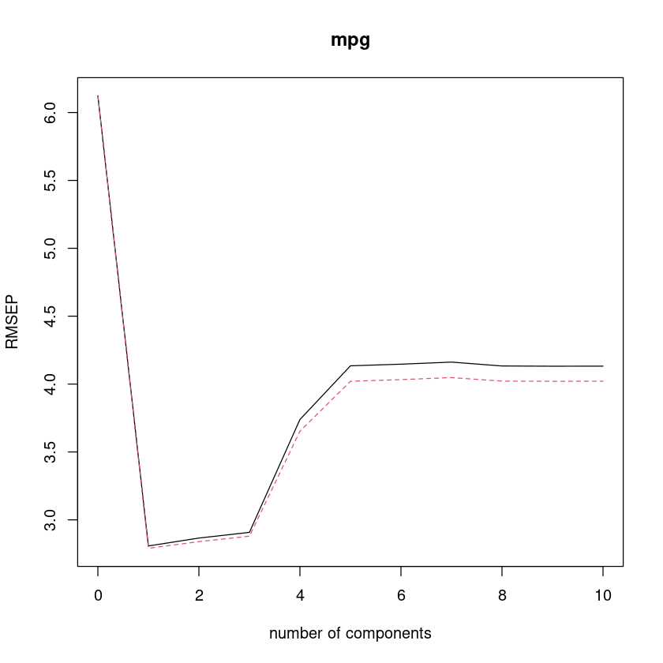

```r
#make the result reproducible
set.seed(526)
#Fit PCR model
#scale=TRUE: variables scaled to have a mean of 0 and a standard deviation of 1.  (highly recommended)
#validation="CV",  k-fold cross-validation to evaluate the performance of the model.
fit.pls = plsr(mpg~., data=mtcars, scale=TRUE, validation="CV")
summary(fit.pls)
#RMSEP against the number of PLS components
validationplot(fit.pls)
#Variance explained
#According to the validaiton plot, we may use just 1 PLS component in the model.
```

If the model uses only one component, the cross validation RMSEP is 2.808; if the models uses two components, the cross validation RMSEP is 2.866. The model with one PLS component has the lowest RMSE. We may select PLS model with one component.

% variance explained (genelization of $R^2$): if the model uses only one PLS component, about 83.18% of the variation in mpg can be explained by the model with one PLS component; if the model uses two components, about 85.39% information in mpg can be explained by the model with two PLS components. According to "% variance explained", we may select either the model with one component or the model with two components.

Implementation of pls using "train" function in caret package.

```r
library(caret)
#Repeated k-fold cross valiation , with 5 repeats
#tuning paramter :   the number of components  (hyperparamerter)
#PLS has one tuning parameter to train
#tuneLength = 8  :  there are 8 possible tuning parameters
set.seed(143)
ctrl = trainControl(method = "repeatedcv", repeats = 5)

pls.fit = train(mpg ~ ., data = mtcars, method = "pls",
                preProc = c("center", "scale"), tuneLength = 8, trControl = ctrl)

#Find the best tuning parameter
pls.fit$bestTune
#summarize the best model selected
summary(pls.fit$finalModel)

#The hyperparameter: the number of PLS components
#The model using 1 PLS component is selected. About 83.18% information in mpg is explained by PLS model with 1 component.
```

A data.frame: 1 × 1

|  | ncomp <dbl> |
| --- | --- |
| 1 | 1 |

```
Data: 	X dimension: 32 10
	Y dimension: 32 1
Fit method: oscorespls
Number of components considered: 1
TRAINING: % variance explained
          1 comps
X           57.58
.outcome    83.18
```

```r
#Create a training set and a test set
#creating training data as 75% of the dataset
train.index  =  createDataPartition(mtcars$mpg, p = 0.75, list = FALSE)

#generating training dataset
#from the random_sample
training.dat =  mtcars[train.index, ]

#generating testing dataset
#from rows which are not included in training set
testing.dat  =  mtcars[-train.index, ]

set.seed(143)
# 4 folds cross validation
ctrl = trainControl(method = "cv", number = 4)

pls.fit.1 = train( mpg ~ ., data = training.dat, method = "pls",
                preProc = c("center", "scale"), tuneLength = 8, trControl = ctrl)

pls.fit.1

#To make prediction using the selected model with 1 pls component
new.dat = testing.dat
fit.pred = predict(pls.fit.1, new.dat, ncomp=1)
fit.pred

#The error
```

```
Partial Least Squares

25 samples
10 predictors

Pre-processing: centered (10), scaled (10)
Resampling: Cross-Validated (4 fold)
Summary of sample sizes: 18, 19, 19, 19
Resampling results across tuning parameters:

  ncomp  RMSE      Rsquared   MAE
  1      2.696578  0.8963030  2.224655
  2      2.789263  0.8703170  2.336641
  3      3.062694  0.8499677  2.523482
  4      3.764997  0.7086629  3.078206
  5      4.382403  0.5727914  3.491748
  6      5.223706  0.5090057  4.123176
  7      6.086112  0.5219511  4.857070
  8      6.435041  0.5102868  5.098530

RMSE was used to select the optimal model using the smallest value.
The final value used for the model was ncomp = 1.
```

1. 21.2545816814628

2. 15.7735984782965

3. 20.9690746905178

4. 27.9094354437653

5. 13.9688655468625

6. 19.789420172283

7. 13.8753513446039

```
[1] 8.0398211 2.8354578 2.0319367 0.8388258
```

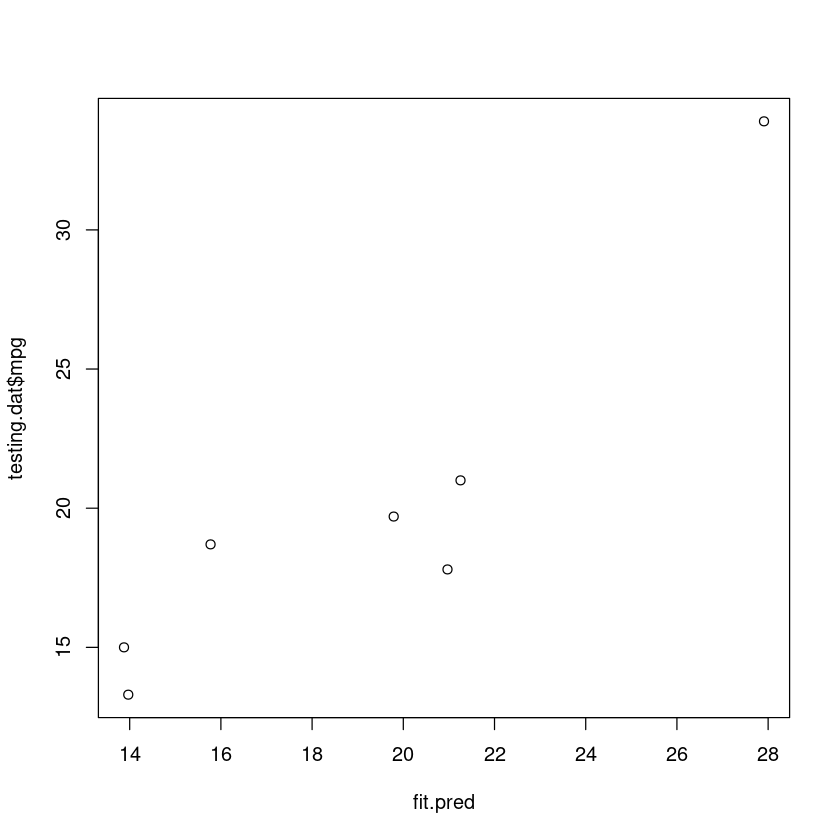

```r
#Plot of the predicted values against the true values
plot(fit.pred, testing.dat$mpg )


#the difference between predicted values and the real observed values
pd.error=fit.pred - testing.dat$mpg

MSE.testing = mean(pd.error^2)
RMSE.testing = sqrt(mean(pd.error^2))
MAD.testing = mean(abs(pd.error))
#R^2
Rsq.Testing = (cor(fit.pred, testing.dat$mpg))^2

print(c(MSE.testing, RMSE.testing, MAD.testing, Rsq.Testing ))

#0.8388258  for Rsq : about 83.8% of information the mpg in the testing data can
#be explained by the training model based on the training data.
```

# Penalized models (Regulation)

The objective funtion for the least squares for a Linear Regression : $$ SSE = \sum_{i=1}^{N} { \left(y_i-\sum_{j=1}^{p}x_{ij}\beta_j \right)^2} $$

Find $\beta$s to minimize SSE ( MSE). If the predictors are highly correlated, or there are multicolinearity issues, there are some disadvantages of this method.

1. Ridge Regression

A penalty term is added to the orinary least squre object function to control multicollinearity. The objective function of the ridge regression is

$$ \sum_{i=1}^{N} { \left(y_i-\sum_{j=1}^{p}x_{ij}\beta_j \right)^2} + \lambda \sum_{j=1}^{p} {\beta_j}^2 $$

In a ridge regression, find $\beta$s to minimize the new objective function. The penalty is a $L_2$ penalty.

The effects of this penality: $$\hat {\bf \beta}_{ridge} = (X^TX + \lambda I)^{-1}X^TY $$.

2. LASSO (Least Absolute Shrinkage and Selection Operator)

LASSO regression encourages variable selection and reduce multicollinearity by shrinking some coefficients to zero.

The objective function of LASSO is $$ \sum_{i=1}^{N} { \left(y_i-\sum_{j=1}^{p}x_{ij}\beta_j \right)^2} + \lambda \underbrace{\sum^{p}_{j=1} \mid{\beta_j}\mid}_{\ell^1-penalisation} $$

3. Elastic Net

Elastic Net combines L1 (Lasso) and L2 (Ridge) regularization, offering a balance between variable selection and coefficient shrinkage. It is more robust and flexible, as it allows you to control the trade-off between Ridge and Lasso regularization through a parameter ($\alpha$).

The objective function is $$ \text{minimize} \frac{1}{2n} { \left(y_i-\sum_{j=1}^{p}x_{ij}\beta_j \right)^2} + \lambda_{1} \sum_{q=1}^{p}|\beta_{qj}| + \lambda_{2} \frac{1}{2}\sum_{q=1}^{p}\beta_{qj}^{2} $$

Rewrite the penalty term into:

when $\alpha $ is 1, the penalty term becomes $$ \lambda \cdot \displaystyle\sum_{j=1}^p |\beta_j| $$

when $\alpha $ is 0, the penalty term becomes $$ \lambda/2 \cdot \displaystyle\sum_{j=1}^p \beta_j^2 $$

Scaling and centering is needed before we run LASSO and Ridge regression to eleminate the effects of the units.